# Weather Effects on Electricity Demand and Grid Stability in Switzerland (2020–2024)

Choung Jihyeon

2026-02-14

# 1 Executive Summary

This report examines how temperature variations relate to electricity demand, grid stress, and stabilization costs in Switzerland using daily data from 2020 to 2024. By integrating national temperature averages with Swissgrid electricity consumption and balancing market indicators, the analysis explores how weather-related demand patterns interact with system flexibility and economic outcomes under extreme conditions.

Exploratory analysis reveals a strong inverse relationship between temperature and electricity demand, with demand increasing during colder periods. After removing weekday-driven cyclical patterns, temperature remains a central explanatory variable, accounting for nearly 70% of short-term demand variability. Seasonal trends further confirm synchronized temperature–demand dynamics in total daily electricity demand.

Grid stress and stabilization costs are analysed across temperature conditions using positive secondary control energy and secondary control energy prices as proxies, focusing on differences in average levels and variability across temperature categories. Additionally, balancing energy prices respond steeply once demand exceeds approximately 2,100 MW, signaling supply inelasticity and heightened system stress.

Building on these findings, two predictive models are developed. A linear regression estimates the sensitivity of demand to temperature, while a logistic regression assesses the probability of entering a critical load regime. The results suggest that temperature declines near freezing levels are associated with disproportionately higher probabilities of system stress.

An operational scenario based on a −7°C forecast illustrates the combined impact of extreme weather conditions. Demand is projected to exceed the critical threshold, the probability of system stress surpasses 90%, and stabilization costs are expected to surge sharply.

In addition, an interactive analysis further examines the relationship between grid stress and stabilization costs at the observation level using positive secondary control energy and secondary control energy prices as proxies.

Overall, the analysis highlights the importance of incorporating temperature-sensitive demand forecasting into threshold-based risk monitoring. Linking demand dynamics with stabilization behavior supports improved anticipation of high-stress regimes during extreme weather conditions.

# 2 Data Foundation

This section introduces the data used throughout the analysis. To explore how temperature, electricity demand, and grid stabilization are connected, we combine national electricity system data from Swissgrid with temperature observations from MeteoSwiss. After aligning and aggregating the datasets to a common daily level, we obtain a consistent time series covering 2020–2024. This dataset forms the basis for examining demand patterns, balancing activity, and the resulting economic impacts under different system conditions.

## 2.1 Data sources and coverage

We combine two daily datasets covering the period 2020–2024: (1) electricity system data from Swissgrid and (2) national temperature data derived from MeteoSwiss station observations.

Swissgrid data were originally provided at a 15-minute resolution. From these files, we selected the relevant time-series variables, including total electricity consumption in the Swiss control block, positive secondary control energy volumes, and corresponding control energy prices. The yearly datasets (2020–2024) were concatenated and aggregated to daily values to ensure consistency with the weather data.

Weather data were obtained from MeteoSwiss daily observations across all meteorological stations in Switzerland. Station-level temperature records were merged, and a national daily mean temperature was computed by averaging across all stations for each day.

The resulting dataset consists of daily observations for 2020–2024 and forms the basis for analyzing temperature–demand relationships, critical load risk, and balancing-related economic impacts.

## 2.2 Data integration (Join) and feature engineering

```r
# Data join : align temperature and demand on the same daily date index
df <- inner_join(temp_data, energy_data, by = "date") %>%
  arrange(date) %>%
  rename(
    temperature     = mean_temp,
    energy_mw        = avg_mw,
    sec_energy_mw    = pos_sec_energy,
    sec_energy_price = pos_sec_price
  )

# Preview of the data
head(df)
```

| date | temperature | energy_mw | sec_energy_mw | sec_energy_price |
| --- | --- | --- | --- | --- |
| 2020-01-01 | -0.6793103 | 1798.951 | 6.799547 | 39.99642 |
| 2020-01-02 | -1.0551724 | 1809.382 | 5.710677 | 47.13208 |
| 2020-01-03 | 1.0310345 | 1858.661 | 2.470979 | 48.18979 |
| 2020-01-04 | 1.7448276 | 1787.869 | 4.144885 | 43.96448 |
| 2020-01-05 | -0.6103448 | 1796.529 | 2.761563 | 45.25323 |
| 2020-01-06 | -0.6344828 | 2049.600 | 2.281115 | 50.85396 |

The two datasets were integrated using a date-based inner join, resulting in a unified daily time series containing temperature, electricity demand, and balancing-related variables.

The main variables used in the analysis are:

- temperature: national daily mean temperature (°C)
- energy_mw: daily electricity demand in the Swiss control block (MW)
- sec_energy_mw: positive secondary control energy volume (MW)
- sec_energy_price: secondary control energy price (EUR/MWh)

Positive secondary control energy represents balancing power activated by the transmission system operator to maintain grid frequency in real time when supply and demand deviate. Higher volumes of secondary control energy typically indicate increased system stress and reduced operational flexibility. In this analysis, secondary control energy is therefore used as a proxy for grid stabilization activity under high-load conditions.

The associated control energy price reflects the market cost of procuring balancing power, capturing the economic impact of stabilization actions during periods of system stress.

# 3 Exploratory Analysis: Temperature–Demand Patterns

This section explores the relationship between temperature and electricity demand before moving to the stabilization and risk analysis. By examining seasonal patterns and daily-level observations, we aim to understand how strongly temperature shapes overall demand dynamics.

## 3.1 Analytical Objectives and Hypotheses

This analysis aims to examine how temperature variations relate to electricity demand and stabilization costs within the Swiss electricity system. We hypothesize that

- Lower temperatures are associated with higher electricity demand.
- Stabilization costs increase nonlinearly under extreme temperature regimes.
- There exists a critical demand threshold beyond which balancing prices and economic risk escalate disproportionately.

These hypotheses structure the subsequent exploratory and modeling analysis.

## 3.2 Macro trend (2022–2024)

We begin the exploratory analysis by examining the macro-level seasonal dynamics between temperature and electricity demand to establish an overall understanding of their co-movement over time.

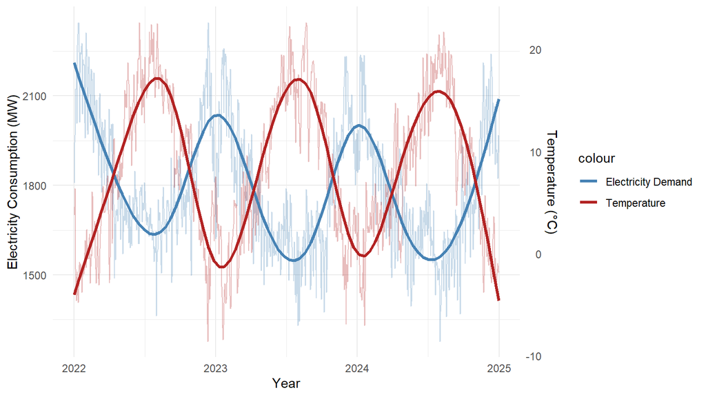

Figure 1. Seasonal co-movement between temperature and electricity demand in Switzerland (2022–2024). Smoothed trends show a strong inverse seasonal pattern.

Figure 1 highlights the macro-level seasonal dynamics between temperature and electricity demand over the 2022–2024 period. The out-of-phase movement of the two series indicates that colder months consistently correspond to higher electricity demand, while warmer months are associated with lower load levels. This pronounced seasonal structure suggests that temperature plays a central role in shaping aggregate electricity consumption patterns.

## 3.3 Raw temperature–demand relationship

While the macro trend highlights strong seasonal co-movement, it does not directly quantify the relationship between temperature and daily demand levels. To further explore this association at the observation level, we next examine the raw temperature–demand relationship using a scatter plot.

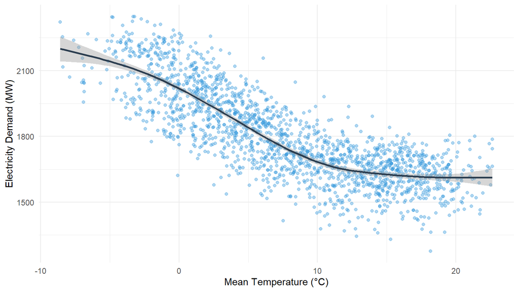

Figure 2. Raw temperature–demand relationship (daily data, 2020–2024).

## 3.4 Weekday-adjusted temperature–demand relationship

The raw relationship suggests a clear inverse association between temperature and demand. However, electricity consumption also exhibits strong weekly cyclical patterns that may obscure the underlying weather-driven effect. To isolate the temperature impact more precisely, we apply STL decomposition to remove weekday seasonality and analyze the adjusted demand series.

**STL decomposition (weekday pattern removal)**

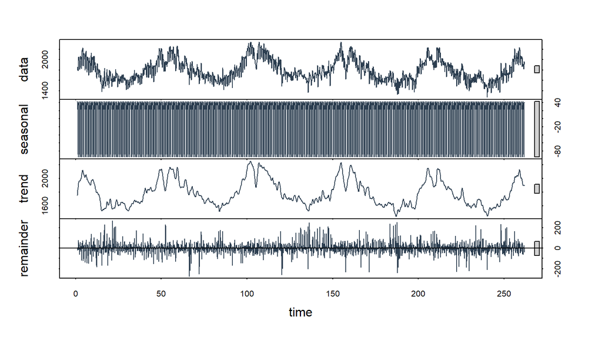

Figure 3. STL decomposition of daily electricity demand (weekly frequency = 7)

The plot shows the observed series and its decomposition into trend, weekly seasonal pattern, and remainder. We use the seasonally adjusted series (observed minus weekly seasonal component) as energy_adjusted.

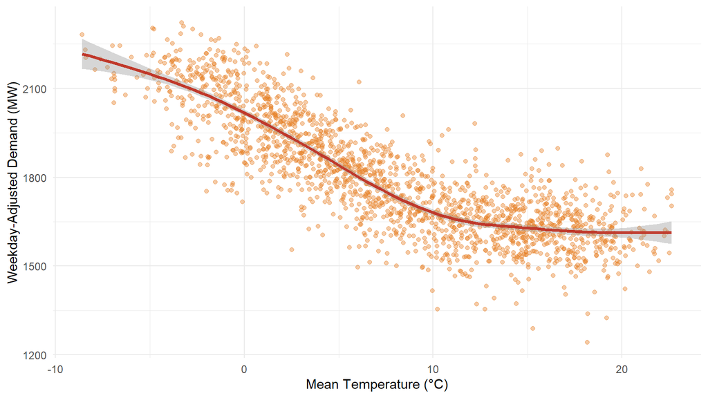

Figure 4. Weekday-adjusted temperature–demand relationship after STL decomposition (weekly cycle removed).

Even after removing weekday-driven fluctuations, a strong inverse relationship between temperature and electricity demand remains clearly visible. This indicates that the observed weather–load pattern is not driven by regular weekly cycles but reflects a fundamental temperature-dependent demand response.

## 3.5 Demand regimes by temperature

After removing weekday-related fluctuations, the temperature–demand relationship remains strong and nonlinear. To further investigate how demand behaves across different temperature regimes and to identify potential threshold effects, we group observations into temperature bins and analyze average demand levels within each range.

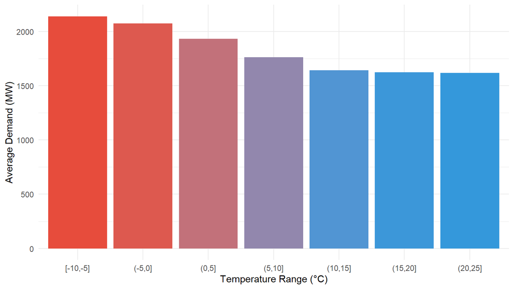

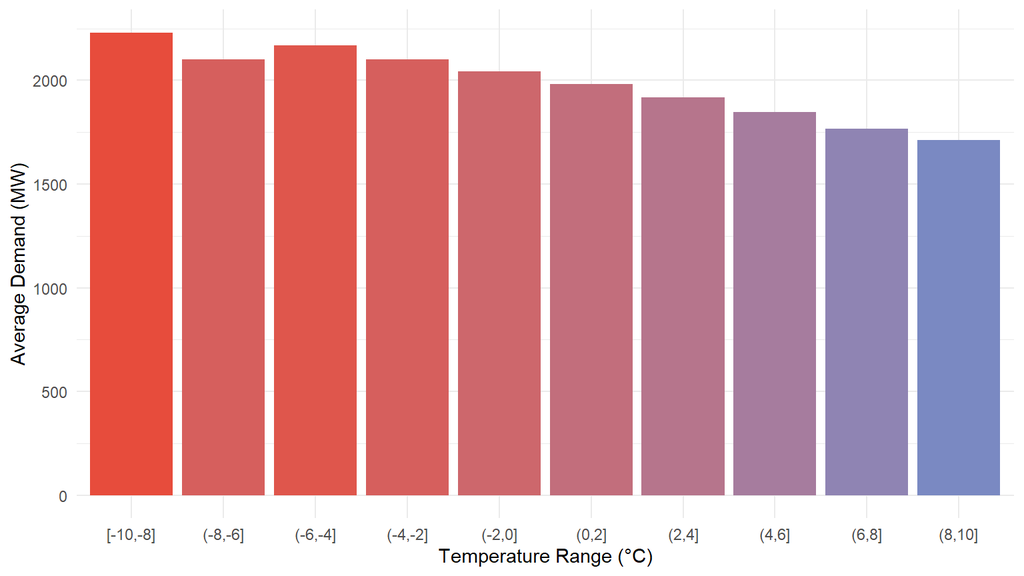

Figure 5. Average electricity demand across temperature regimes using coarse (5°C) and refined (2°C) binning. The refined bins highlight a sharp increase in demand at low temperatures, suggesting a cold-weather threshold where load begins to accelerate rapidly.

To translate the continuous temperature–demand relationship into operationally interpretable regimes, we summarize average demand by temperature bins. While the 5°C bins provide a broad overview of declining demand as temperature increases, the refined 2°C bins reveal a much sharper demand surge at low temperatures. This pattern suggests the presence of a critical cold-weather threshold where load begins to increase rapidly.

# 4 Grid Stability & Economic Risk Signals

Beyond the analysis of electricity demand, it is important to consider how the power system responds operationally under different conditions. In particular, extreme weather situations may require additional interventions to maintain grid stability, thereby affecting both operational effort and associated costs.

This chapter provides a transition from a demand-focused perspective to an examination of system-level responses of the electricity grid. The following sections examine different aspects of grid stabilization and associated costs.

## 4.1 Price Dynamics under Temperature and Load Stress

This section examines how grid stress varies across different temperature conditions. Grid stress is not measured directly but is proxied by the activation of positive secondary control energy, which reflects the balancing effort required to maintain system stability. In addition, secondary control energy prices are analyzed as an economic indicator of stabilization costs.

To ensure comparability across the individual sub-sections, temperature values are grouped into fixed intervals that are applied consistently throughout this chapter. These temperature categories form the common structural basis for all subsequent analyses, while their specific implications for grid stress and stabilization costs are discussed in the respective sub-sections.

### 4.1.1 Mean and distribution grid stress across temperature bins

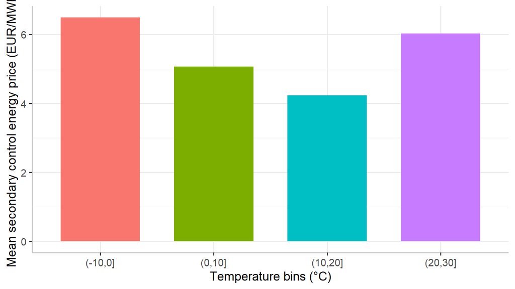

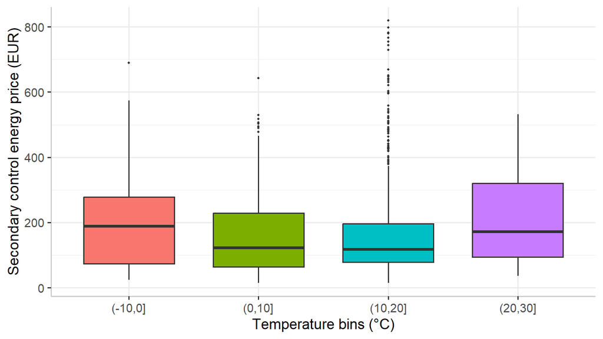

Figure 6. Mean and distribution of secondary control energy prices across temperature bins.

The left panel shows the average secondary control energy price across predefined temperature bins. A clear pattern appears: prices are lowest in the moderate temperature range (10–20°C) and increase under both colder and warmer conditions. In particular, temperatures below 0°C are associated with noticeably higher average prices, indicating greater stabilization costs during cold periods. Warm conditions (20–30°C) also show elevated prices, though the increase is less pronounced than in extreme cold.

Overall, the results suggest that both cold and warm temperature extremes are linked not only to higher average stabilization costs but also to greater price uncertainty. In contrast, moderate temperature bins correspond to more stable and cost-efficient grid conditions.

### 4.1.2 Relationship between grid stress and price of secondary control energy

[interactive chart not shown]

Figure 7. Relationship between secondary control energy deployment and balancing prices, colored by year (2020–2024). Higher activation levels are associated with elevated and more volatile prices, with notable differences across years reflecting changing market conditions.

The scatter plot shows how secondary control energy deployment relates to balancing prices, with observations colored by year. A positive relationship is visible: higher activation levels are generally associated with higher prices and greater price dispersion.

However, the strength of this relationship varies across years. In 2020, prices remain relatively low and stable even at moderate activation levels. In contrast, 2022 stands out with substantially higher prices and frequent extreme spikes, even when activation volumes are comparable to earlier years. The years 2023 and 2024 show elevated price levels relative to 2020, though less extreme than 2022.

This pattern indicates that while grid stress increases cost pressure, the magnitude of economic exposure depends on broader market conditions. Elevated activation raises the likelihood of high prices, but the intensity of price responses differs across market regimes.

## 4.2 Realized Stabilization Cost and Nonlinear Risk Thresholds

While Section 4.1 analyzed secondary control energy prices as market signals of system stress, this section shifts the focus from price dynamics to realized economic exposure. By combining control energy prices with actual activation volumes, we quantify the effective stabilization costs incurred under different temperature and load regimes.

**Stabilization Cost = Secondary Control Energy × Control Energy Price**

```r
# Create a new column for realized stabilization cost (MW × price).
df <- df %>%
  mutate(
    stabilization_cost = sec_energy_mw * sec_energy_price,
  )
```

This proxy captures the economic magnitude of balancing actions associated with grid stress.

### 4.2.1 Temperature-driven cost escalation

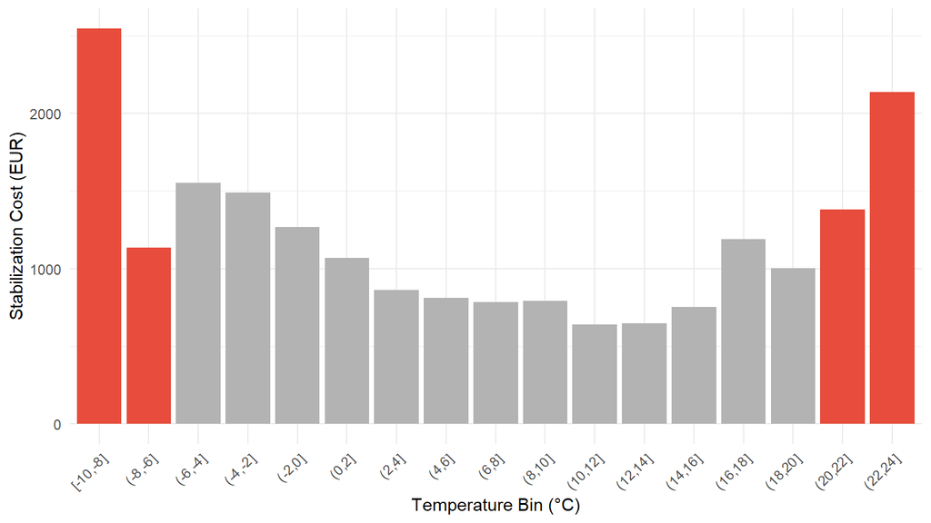

Figure 11. Stabilization cost response across temperature regimes (2°C bins).Average daily stabilization costs exhibit a pronounced U-shaped pattern, with sharp cost escalation during extreme cold conditions and secondary increases at high summer temperatures.

In contrast, while high summer temperatures are also associated with rising costs, the slope of increase appears less abrupt than in the extreme cold regime. This asymmetry indicates that cold-driven demand spikes exert stronger stress on the balancing system compared to heat-driven effects within the observed period.

Overall, the figure highlights that stabilization cost risk is not evenly distributed across temperature ranges but concentrates around identifiable stress regimes, supporting the threshold-based operational framework introduced in this section.

### 4.2.2 Demand-driven price escalation

To examine whether high system load amplifies balancing price pressure, we analyze the relationship between total electricity demand and secondary control energy prices.

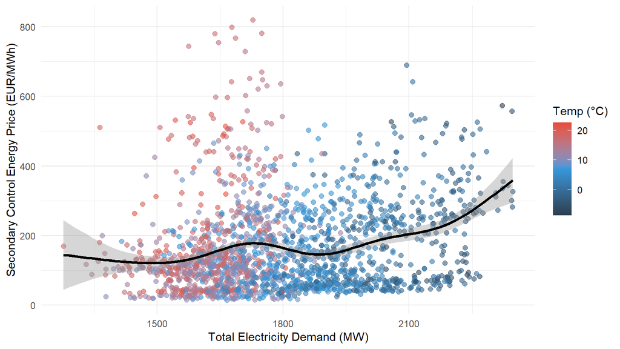

Figure 12. Relationship between electricity demand and secondary control energy prices.Prices remain relatively stable at moderate demand levels but increase sharply beyond high-load regimes, indicating supply inelasticity under system stress.

The relationship between total electricity demand and secondary control energy prices shows a clear nonlinear pattern. At moderate demand levels, prices remain relatively stable, suggesting that the system has sufficient balancing capacity and operational flexibility.

However, as demand approaches and exceeds roughly 2,100 MW, the pattern changes. Prices begin to rise more rapidly and become more dispersed. This indicates tightening reserve margins and reduced market flexibility under high-load conditions.

Colder temperature observations (shown as darker blue points) are concentrated in this high-demand region. This reinforces the link between temperature-driven load increases and upward pressure on balancing prices.

The observed inflection around 2,100 MW provides the empirical basis for defining this level as a critical operational threshold. While it does not represent a hard physical limit, it marks the transition from stable operating conditions to a more stress-sensitive regime, where additional demand leads to disproportionately larger price responses.

### 4.2.3 Operational risk threshold definition

The nonlinear price pattern shown in Figure 12 provides the empirical basis for defining a critical load threshold. We set 2,100 MW as the boundary for high-load conditions in the subsequent modeling. While this value is not a strict physical system limit, it marks the point where price behavior shifts from relatively stable to clearly stress-sensitive.

To capture this shift, we construct a binary indicator that distinguishes between demand levels below and above 2,100 MW. This transforms the observed nonlinear price response into a clear risk-state variable that can be used in predictive analysis.

```r
# Create a binary indicator for critical load conditions based on a predefined demand threshold (≥ 2100 MW).
df <- df %>%
  mutate(
    is_critical = ifelse(energy_mw >= 2100, 1, 0)
  )
```

Ideally, the definition of a critical load threshold would rely on internal reserve margin or system constraint data from the transmission operator. Since such detailed operational data are not publicly available, the empirically identified 2,100 MW level serves as a transparent, data-driven proxy for high-risk conditions.

This approach connects the descriptive price analysis with the predictive risk model, allowing clearer monitoring of when stabilization costs begin to escalate disproportionately.

# 5 Predictive Modeling & Operational Simulation

Having identified clear nonlinear cost patterns and a critical load threshold, we now turn to predictive modeling. The goal is to quantify temperature sensitivity in electricity demand and translate observed patterns into a structured modeling framework. This step allows us to simulate system behavior under different temperature scenarios and assess potential operational risk.

## 5.1 Model 01: Quantifying Demand Sensitivity

```r
# Estimate a linear regression model to assess the effect of temperature on adjusted electricity demand.
load_model <- lm(energy_adjusted ~ temperature, data = df)
summary(load_model)
```

```
##
## Call:
## lm(formula = energy_adjusted ~ temperature, data = df)
##
## Residuals:
##     Min      1Q  Median      3Q     Max
## -386.43  -72.25    0.41   75.30  347.17
##
## Coefficients:
##             Estimate Std. Error t value Pr(>|t|)
## (Intercept) 1982.621      3.900  508.31   <2e-16 ***
## temperature  -23.600      0.372  -63.45   <2e-16 ***
## ---
## Signif. codes:  0 '***' 0.001 '**' 0.01 '*' 0.05 '.' 0.1 ' ' 1
##
## Residual standard error: 110.4 on 1825 degrees of freedom
## Multiple R-squared:  0.6881, Adjusted R-squared:  0.6879
## F-statistic:  4026 on 1 and 1825 DF,  p-value: < 2.2e-16
```

### 5.1.1 Model Interpretation

The relationship is modeled as:
$$D(T) =
\alpha + \beta T$$
Based on the regression results, the fitted model is:
$$\widehat{D}(T) = 1982.62 -
23.60T$$

where $\widehat{D}(T)$ denotes daily electricity demand and $T$ represents mean daily temperature.

The linear specification provides a clear baseline for measuring average temperature sensitivity. Although the temperature–demand relationship may show some curvature at extreme values, the linear model offers an interpretable first-order approximation of how demand responds to temperature changes. This makes it particularly useful for scenario analysis and threshold forecasting.

The estimated temperature coefficient is −23.6 MW per °C, meaning that a one-degree decrease in temperature is associated with an average increase of approximately 23.6 MW in daily electricity demand. The model explains a substantial share of demand variation (R² = 0.688), indicating that temperature is a major factor of short-term electricity consumption.

### 5.1.2 Model Diagnostics

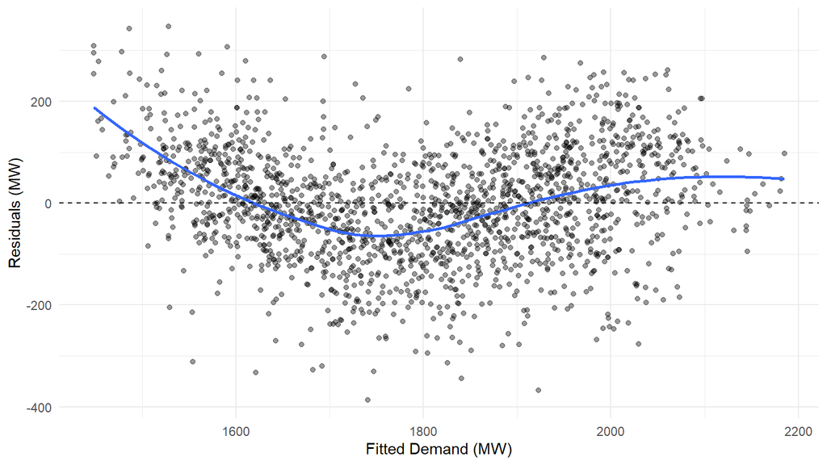

## 5.2 Model 02: Probability of Critical Load Events

```r
# Model the probability of critical load using temperature as predictor.
risk_model <- glm(is_critical ~ temperature, data = df, family = binomial)
summary(risk_model)
```

```
##
## Call:
## glm(formula = is_critical ~ temperature, family = binomial, data = df)
##
## Coefficients:
##             Estimate Std. Error z value Pr(>|z|)
## (Intercept) -1.16214    0.10044  -11.57   <2e-16 ***
## temperature -0.48423    0.03481  -13.91   <2e-16 ***
## ---
## Signif. codes:  0 '***' 0.001 '**' 0.01 '*' 0.05 '.' 0.1 ' ' 1
##
## (Dispersion parameter for binomial family taken to be 1)
##
##     Null deviance: 1175.94  on 1826  degrees of freedom
## Residual deviance:  650.24  on 1825  degrees of freedom
## AIC: 654.24
##
## Number of Fisher Scoring iterations: 8
```

To estimate the probability of entering a critical load regime (demand ≥ 2,100 MW), we model the relationship between mean daily temperature ($T$) and event probability ($p$) using logistic regression.

### 5.2.1 Model Interpretation

The estimated model is:

$$\ln\left(\frac{p}{1-p}\right) = -1.16214
- 0.48423T$$
This equation describes how temperature affects the log-odds of a critical load event.

- Intercept ($\beta_0 = -1.162$) : Represents the log-odds of a critical load event at $0^\circ\text{C}$.
- Temperature Coefficient ($\beta_1 = -0.484$) : For each $1^\circ\text{C}$ increase in temperature, the log-odds of a critical event decrease by 0.484.

Odds are multiplied by
$$e^{-0.484} \approx 0.62$$
This corresponds to a 38% reduction in odds per 1°C increase.

### 5.2.2 Probability Representation

For practical interpretation, the model can be written as:

$$p(T) = \frac{1}{1 + e^{-(-1.162 -
0.484T)}}$$

This form directly gives the probability (0–100%) of a critical event at any temperature. As temperature decreases, $p(T)$ increases nonlinearly, reflecting rising system stress under cold conditions.

### 5.2.3 Operational Risk Levels by Temperature

Table 1: Probability of Critical Load by Temperature

| Mean Temperature (T) | Calculated Probability (p) | Risk Level |
| --- | --- | --- |
| -5°C | 77.9% | High |
| 0°C | 23.8% | Moderate |
| 5°C | 2.7% | Low |

Table 1 translates the logistic model into actionable risk categories. The results highlight the strong nonlinear sensitivity of system stress to temperature.

At −5°C, the probability of entering a critical load regime approaches 78%, indicating a high likelihood of capacity pressure under severe cold conditions. In contrast, at 5°C, the probability falls below 3%, suggesting minimal operational risk. The sharp increase in probability between 0°C and −5°C reflects the threshold-like behavior captured by the logistic specification.

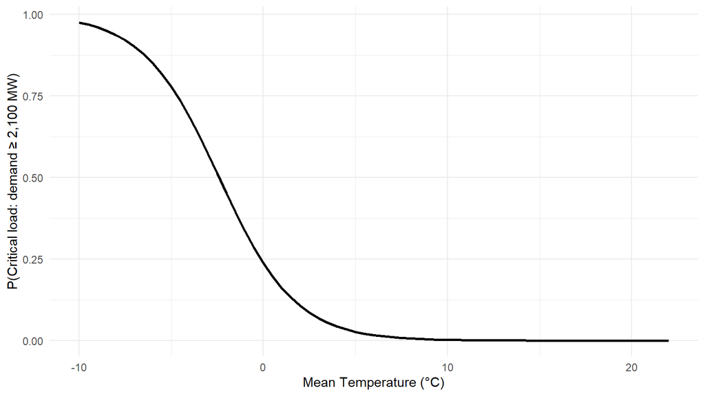

Figure 14. Predicted probability of entering the critical load regime (demand ≥ 2,100 MW) as a function of temperature.

The predicted probability curve exhibits a pronounced inflection around 0°C. As temperatures fall below freezing, the likelihood of exceeding the 2,100 MW threshold increases rapidly, suggesting an accelerating transition into high-stress operating regimes.

This nonlinearity is operationally important. While average demand increases gradually as temperatures decline, the probability of crossing the critical threshold accelerates rapidly once temperatures approach freezing levels. This suggests that system preparedness measures should intensify disproportionately during cold spells rather than scaling linearly with forecasted demand.

## 5.3 Operational scenario: −7°C forecast

To illustrate the practical implications of the modeling framework, we simulate an extreme cold-weather scenario with a forecasted mean temperature of −7°C.

```r
# Perform calculations with −7°C
new_temp <- data.frame(temperature = -7)
pred_demand <- predict(load_model, new_temp)
pred_prob   <- predict(risk_model, new_temp, type = "response")

# Create and format the data frame
scenario_df <- data.frame(
  temperature = "-7°C",
  predicted_demand = paste0(round(pred_demand, 1), " MW"),
  prob_critical = paste0(round(pred_prob * 100, 1), "%")
)

# Render the table
scenario_df %>%
  kable(
    col.names = c("Temperature", "Predicted Demand", "Probability of Critical Load"),
    align = "lll", # Left-aligned to match your previous table
    caption = "Table 2: Scenario Analysis for Extreme Cold Event"
  )
```

Table 2: Scenario Analysis for Extreme Cold Event

| Temperature | Predicted Demand | Probability of Critical Load |
| --- | --- | --- |
| -7°C | 2147.8 MW | 90.3% |

At −7°C, the linear demand sensitivity model predicts a daily electricity demand of approximately 2,148 MW, exceeding the defined critical threshold of 2,100 MW. Simultaneously, the logistic risk model estimates a 90.3% probability of entering the critical load regime. Together, these results indicate that extreme cold conditions are not only associated with higher demand but also with a substantially elevated likelihood of operating in a high-stress system state.

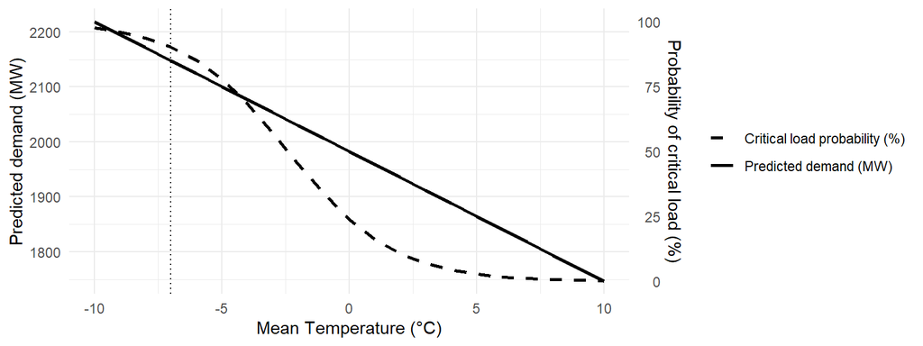

Figure 15. Scenario sensitivity of demand and critical-load risk across cold temperatures. Vertical line indicates the −7°C forecast scenario.

Figure 15 illustrates the relationship between total demand and system risk. The linear model provides a steady baseline for how demand increases as temperatures fall. In contrast, the logistic model captures the nonlinear “tipping point” in system stability.

# 6 Conclusion

This analysis examined how temperature-driven demand patterns interact with grid stabilization and cost dynamics in the Swiss electricity system. While electricity demand increases gradually under colder conditions, system responses in terms of balancing effort and stabilization costs rise nonlinearly once high-load thresholds are approached.

The findings show that rising demand alone does not fully explain periods of elevated costs. Rather, temperature-driven load increases interact with limited system flexibility, resulting in disproportionately higher balancing activity and costs once critical load levels are exceeded. This suggests that operational risk intensifies around identifiable stress thresholds, rather than increasing gradually over time.

In addition, the relationship between grid stress and balancing prices varies across years, indicating that economic exposure is influenced not only by activation levels but also by broader market conditions. Elevated stress increases the likelihood of high and volatile prices, but the magnitude of cost escalation depends on the prevailing market regime.

Overall, the results highlight the importance of integrating temperature-sensitive demand modeling into stabilization planning. Combining demand forecasts with threshold-based risk monitoring can improve early identification of high-stress conditions and support more informed operational decisions during extreme weather events.

# 7 Limitations

This analysis focuses on temperature as the central explanatory variable for electricity demand dynamics. While temperature explains a substantial share of short-term demand variability, the model does not explicitly account for other temporal influences such as calendar effects beyond weekday adjustment, short-term behavioral changes, or exceptional events. As a result, part of the remaining demand variation may reflect factors not captured in the temperature-based framework.

Furthermore, grid stress and stabilization costs are assessed using proxy indicators derived from secondary control energy volumes and prices. While these variables provide a meaningful representation of balancing activity and associated economic pressure, they do not capture all operational dimensions of grid stability. In particular, secondary control energy reflects activated balancing needs but does not directly measure system constraints, reserve availability, or operational decision-making processes within the transmission system.

Finally, the analysis is based on historical observations from 2020–2024 and assumes stable structural relationships over time. Changes in market conditions, system flexibility, or operational strategies may influence future temperature–risk relationships, which limits the direct generalizability of the results beyond the observed period.